# MIE1517H Final Project: Food Nutrition Predictor

By team 14: Siddharth Joshi, Georgia Jovanovic, Eliam Pham and Glenn Shimoda

**Project github**: https://github.com/TakShimoda/MIE1517-Project-Nutrition-Predictor

**Notebook URL**: https://colab.research.google.com/drive/1mNxLZ_hZJt8fGNcRFx64GLT-ykMhlneG?authuser=2

**Link to pre-computed ResNet152 features**: https://drive.google.com/drive/folders/19L7-AfptW5UarLS_LxdAuUyPWiBgBjhl?usp=drive_link

**Link to notebook testing on augmented data**: https://colab.research.google.com/drive/14Nnjt3RZMbta4YJXUN5wGmVNc4xmw0q9?authuser=2

**Link to augmented dataset 1**: https://drive.google.com/drive/folders/1F5IxzuwWUTHFbKgcQa5294VPN9zQZsUQ?usp=drive_link

**Link to augmented dataset 2**: https://drive.google.com/drive/folders/1cwyFb3ZKpV_8F66UfUf85SNry5LGUdAi?usp=drive_link

## Project Overview

### Motivation

A nutritious and balanced diet is one of the most important things for a healthy lifestyle. However, this can be a tedious task; one must count all the nutrient values of the ingredients used in their meal, and also estimate how certain preparation processes (such as stir-frying, deep-frying, boiling, etc.) can affect it. It is also not an exact science, as exact quantities of foods usually aren't measured. A convenient workaround would be to take images of a meal and process them through a learned model that can make rough predictions on certain amounts of nutrients in the meal, such as calories, carbohydrates, proteins, and fats.

### Our Solution

We propose to use the power of transfer learning to build a lightweight convolutional neural network that can predict amounts of calories (kcal), carbohydrates (g), proteins (g), and fat (g).

Our project can be broken down in the following steps:

1. We use a ResNet152 model pre-trained on the [Food-2K](http://123.57.42.89/FoodProject.html) dataset (provided [here](https://github.com/Liuyuxinict/prenet)) with the last layer removed, and then we pass images from the Food-100K dataset to this model to extract 2048-dimensional features. All the steps here can be found in the file **feature_extraction.ipynb** in the provided github link.
2. Train a regression model with 4 output neurons, using the extracted features from step 1). This model makes predictions on: 1) calories (kcal), 2) protein (g), 3) carbohydrates (g), 4) fat (g)
3. Test on unseen images from the dataset, as well as new images with human annotated nutritional information, as well as comparing against a baseline method.

Our pipeline can be summarized in the image below:

```python
from IPython.display import SVG, display
display(SVG(filename='/content/drive/MyDrive/MIE1517 Project/nutrition_predictor.svg'))
```

[figure not shown]

# Step 0: Mount to Drive and Imports

```python
from google.colab import drive
drive.mount('/content/drive')
```

```python
import os
from datasets import load_dataset, Image as HFImage, DatasetDict
import json
import pandas as pd
import matplotlib.pyplot as plt
import numpy as np
```

# Step 1. Load and explore the dataset

We will be exploring the dataset, where many of the same steps were performed in **feature_extraction.ipynb**

```python
dataset = load_dataset("Codatta/MM-Food-100K")
```

```python
# The dataset contains 100,000 images
print(dataset)
print(f'Number of features: {len(dataset['train'].features)}')
print(f'Length of dataset: {len(dataset)}')
```

```
DatasetDict({
    train: Dataset({
        features: ['image_url', 'camera_or_phone_prob', 'food_prob', 'dish_name', 'food_type', 'ingredients', 'portion_size', 'nutritional_profile', 'cooking_method', 'sub_dt'],
        num_rows: 100000
    })
})
Number of features: 10
Length of dataset: 1
```

### Step 1a. Split the dataset into training/validation/test sets

```python
train_test_split = dataset['train'].train_test_split(test_size=0.1, seed=42)
train_val_split = train_test_split['train'].train_test_split(test_size=0.11, seed=42)

# merge back into a single DatasetDict
dataset = DatasetDict({
    'train': train_val_split['train'],
    'validation': train_val_split['test'],
    'test': train_test_split['test']
})

print(dataset)
```

```
DatasetDict({
    train: Dataset({
        features: ['image_url', 'camera_or_phone_prob', 'food_prob', 'dish_name', 'food_type', 'ingredients', 'portion_size', 'nutritional_profile', 'cooking_method', 'sub_dt'],
        num_rows: 80100
    })
    validation: Dataset({
        features: ['image_url', 'camera_or_phone_prob', 'food_prob', 'dish_name', 'food_type', 'ingredients', 'portion_size', 'nutritional_profile', 'cooking_method', 'sub_dt'],
        num_rows: 9900
    })
    test: Dataset({
        features: ['image_url', 'camera_or_phone_prob', 'food_prob', 'dish_name', 'food_type', 'ingredients', 'portion_size', 'nutritional_profile', 'cooking_method', 'sub_dt'],
        num_rows: 10000
    })
})
```

### Step 1b. Visualize 5 random samples from the training set

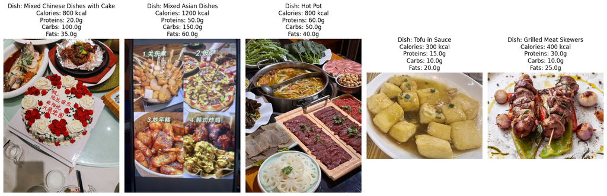

```python
# cast the 'image_url' column to the Image type
dataset_vis = dataset.cast_column('image_url', HFImage())

# access the training split
train_data = dataset_vis['train']

# pick examples and setup plotting
num_to_show = 5

fig, axes = plt.subplots(1, num_to_show, figsize=(18, 8))

for i in range(num_to_show):
    item = train_data[i]

    # display image
    axes[i].imshow(item['image_url'])
    axes[i].axis('off')

    # handle the metadata safely
    profile = item['nutritional_profile']

    # if it's still a string, convert it to a dictionary
    if isinstance(profile, str):
        profile = json.loads(profile.replace("'", '"')) # standardize quotes for JSON

    # extract info for the title
    dish = item['dish_name']
    calories = profile.get('calories_kcal', 'N/A')
    proteins = profile.get('protein_g', 'N/A')
    carbs = profile.get('carbohydrate_g', 'N/A')
    fat = profile.get('fat_g', 'N/A')

    axes[i].set_title(f"Dish: {dish}\nCalories: {calories} kcal\nProteins: {proteins}g\nCarbs: {carbs}g\nFats: {fat}g", fontsize=12)

plt.tight_layout()
plt.show()
```

### Step 1c. Cast nutrition data to float and add to the dataset

As the dataset exists, it has one column for "nutritional_profile" which has all the names and values as a string. Extract calories, carbohydrates, proteins, and fats separately into their own feature column.

```python
def get_nutrition(example, string):
    """
    Extracts calories, carbohydates, proteins, and fats from the nutritional_profile feature as numeric values
    """
    profile = example['nutritional_profile']
    # Split the string to get the nutrient name (e.g., 'carbohydrate')
    nutrition_name = string.split('_')[0]

    # if it's a string, parse it to a dict
    if isinstance(profile, str):
        try:
            profile = json.loads(profile.replace("'", '"'))
        except:
            return {nutrition_name: None}

    # extract the specific nutritional value using the full string (e.g., 'calories_kcal')
    nutrition_amt = profile.get(string)
    return {nutrition_name: float(nutrition_amt) if nutrition_amt is not None else None}
```

```python
nutrients = ['carbohydrate_g', 'fat_g', 'protein_g', 'calories_kcal']
for n in nutrients:
  # Pass the 'n' variable as an argument to get_nutrition using fn_kwargs
  dataset = dataset.map(get_nutrition, fn_kwargs={'string': n})
```

```python
# print dataset's features
print(dataset['train'].features)
print(dataset['validation'].features)
print(dataset['test'].features)
```

```
{'image_url': Value('string'), 'camera_or_phone_prob': Value('float64'), 'food_prob': Value('float64'), 'dish_name': Value('string'), 'food_type': Value('string'), 'ingredients': Value('string'), 'portion_size': Value('string'), 'nutritional_profile': Value('string'), 'cooking_method': Value('string…
{'image_url': Value('string'), 'camera_or_phone_prob': Value('float64'), 'food_prob': Value('float64'), 'dish_name': Value('string'), 'food_type': Value('string'), 'ingredients': Value('string'), 'portion_size': Value('string'), 'nutritional_profile': Value('string'), 'cooking_method': Value('string…
{'image_url': Value('string'), 'camera_or_phone_prob': Value('float64'), 'food_prob': Value('float64'), 'dish_name': Value('string'), 'food_type': Value('string'), 'ingredients': Value('string'), 'portion_size': Value('string'), 'nutritional_profile': Value('string'), 'cooking_method': Value('string…
```

### Step 1d. Nutrition statistics

Get an idea of the nutritional values in the dataset to contextualize what we're working with, and what is a reasonable performance for a model to predict these values.

Go through summary statistics of each of the 4 values. The max values are used for normalization as shown in **feature_extraction.ipynb**, while mean/can help contextualize how accurate a regression model is given the magnitude of its error relative to them.

```python
cal_stats = pd.Series(dataset['train']['calories']).describe().round(2)

print('--- Calories Statistics ---')
print(cal_stats)
```

```
--- Calories Statistics ---
count    80100.00
mean       411.24
std        256.60
min          0.00
25%        250.00
50%        350.00
75%        600.00
max       3500.00
dtype: float64
```

```python
carb_stats = pd.Series(dataset['train']['carbohydrate']).describe().round(2)

print('--- Carbohydrate Statistics ---')
print(carb_stats)
```

```
--- Carbohydrate Statistics ---
count    80100.00
mean        40.54
std         29.12
min          0.00
25%         20.00
50%         35.00
75%         60.00
max        650.00
dtype: float64
```

```python
fat_stats = pd.Series(dataset['train']['fat']).describe().round(2)

print('--- Fat Statistics ---')
print(fat_stats)
```

```
--- Fat Statistics ---
count    80100.00
mean        17.57
std         15.03
min          0.00
25%         10.00
50%         15.00
75%         25.00
max        250.00
dtype: float64
```

```python
protein_stats = pd.Series(dataset['train']['protein']).describe().round(2)

print('--- Protein Statistics ---')
print(protein_stats)
```

```
--- Protein Statistics ---
count    80100.00
mean        21.38
std         18.12
min          0.00
25%          5.00
50%         20.00
75%         30.00
max        250.00
dtype: float64
```

Now plot histograms and box-and-whisker plots for the values. It is important to identify if the distributions are skewed and if outliers may affect the data

```python
def plot_statistics(stat, unit):
  nutrients = dataset['train'][stat]
  stat = stat.capitalize()

  fig, (ax1, ax2) = plt.subplots(1, 2, figsize=(16, 6))

  # Histogram
  ax1.hist(nutrients, bins=40, color='skyblue', edgecolor='black', alpha=0.7)
  ax1.set_title(f'Histogram of {stat}', fontsize=14)
  ax1.set_xlabel(f'{stat} ({unit})', fontsize=12)
  ax1.set_ylabel('Frequency', fontsize=12)
  ax1.grid(axis='y', linestyle='--', alpha=0.6)

  # Box Plot
  ax2.boxplot(nutrients, vert=False, patch_artist=True,
              boxprops=dict(facecolor='lightgreen', color='black'),
              medianprops=dict(color='red', linewidth=2))
  ax2.set_title(f'Box Plot of {stat}', fontsize=14)
  ax2.set_xlabel(f'{stat} ({unit})', fontsize=12)
  # ax2.set_yticklabels(['Training Set'])
  ax2.grid(axis='x', linestyle='--', alpha=0.6)

  plt.suptitle(f'{stat} Distribution Analysis (MM-Food-100K)', fontsize=16, fontweight='bold')
  plt.tight_layout(rect=[0, 0.03, 1, 0.95])
  plt.show()

def plot_histogram(stat):
  nutrients = dataset['train'][stat]
  log_nutrients = np.log1p(np.array(nutrients))

  plt.figure(figsize=(6, 4))
  plt.hist(log_nutrients, bins=40, color='salmon', edgecolor='black', alpha=0.7)

  plt.title('Histogram of Log-Transformed Calories', fontsize=14)
  plt.xlabel('Log(1 + Calories)', fontsize=12)
  plt.ylabel('Frequency', fontsize=12)
  plt.grid(axis='y', linestyle='--', alpha=0.6)

  plt.show()
```

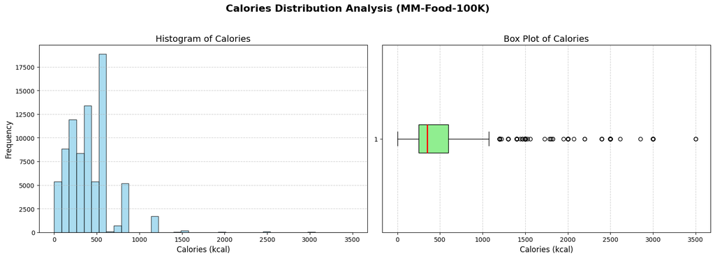

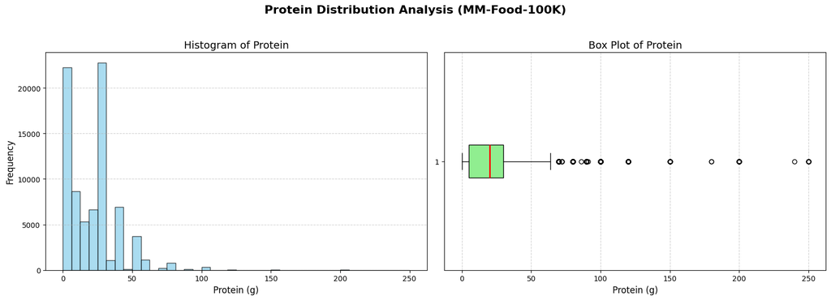

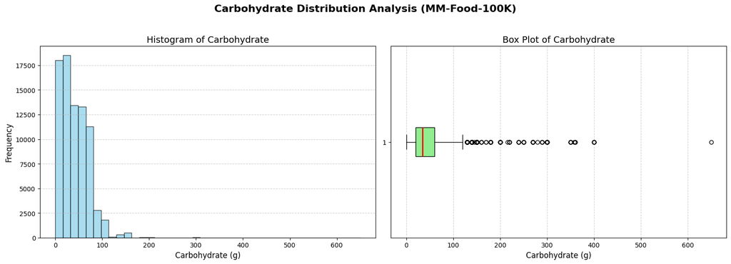

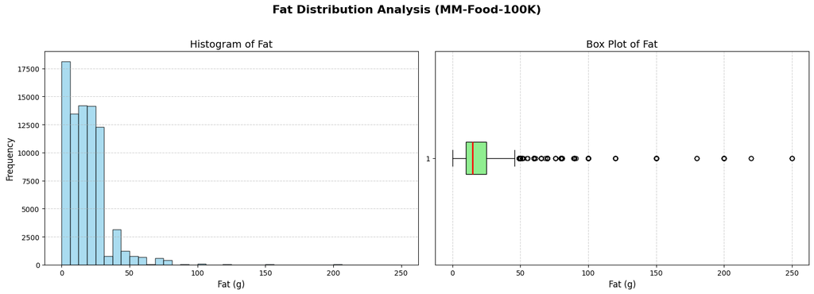

```python
plot_statistics('calories', 'kcal')
plot_statistics('protein', 'g')
plot_statistics('carbohydrate', 'g')
plot_statistics('fat', 'g')
```

Results show that there is some skew in the dataset. For example, there is a strong concentration of meals with 600 calories and it is not a Gaussian distribution. There are no abnormal values which a human can verify, such as protein being over 500g for example.

Now visualize a histogram on log-transformed calories to get a cleaner visualization. Log-transformed labels may be more advantageous for regression if the data distribution is too skewed.

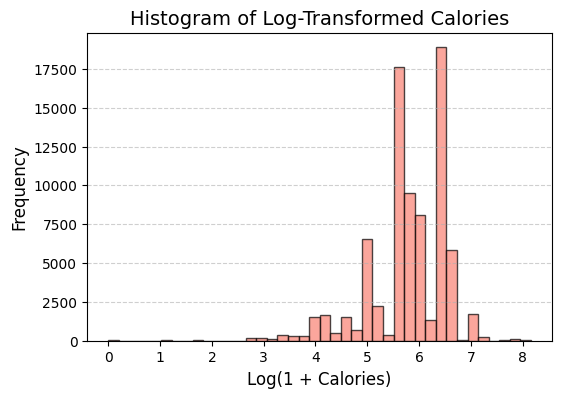

[figure not shown]

[figure not shown]

[figure not shown]

```python
plot_histogram('calories')
plot_histogram('protein')
plot_histogram('carbohydrate')
plot_histogram('fat')
```

Set the max values for each nutritional profile for use in normalization. This was performed in **feature_extraction.ipynb** but is also used here for evaluation of the model.

```python
MAX_CALORIES = cal_stats['max']
MAX_PROTEINS = protein_stats['max']
MAX_CARBS = carb_stats['max']
MAX_FAT = fat_stats['max']
```

# Step 2. Build neural network model

```python
import torch
import torch.nn as nn
from torchvision import models
import torch.optim as optim
```

Our model is a simple dense linear model. it takes in as input the 2048-dimensional features pre-computed by the ResNet152 pre-trained on Food2K. The neurons in the layers are 2048 $\rightarrow$ 512 $\rightarrow$ 256 $\rightarrow$ 4. ReLu is used as the nonlinear activation function, batch normalization is used in the 512 layers, and dropout of 30% is performed afterwards.

```python
device = torch.device("cuda" if torch.cuda.is_available() else "cpu")
print("Using device:", device)

class NutritionPredictor(nn.Module):
    def __init__(self, input_dim=2048, output_dim=4):
        super(NutritionPredictor, self).__init__()
        self.name = 'nutrition_predictor_dropout_256'
        self.regressor = nn.Sequential(
            nn.Linear(input_dim, 512),
            nn.BatchNorm1d(512),
            nn.ReLU(),
            nn.Dropout(0.3),

            nn.Linear(512, 256),
            nn.ReLU(),

            nn.Linear(256, output_dim)
        )

    def forward(self, x):
        return self.regressor(x)

model = NutritionPredictor().to(device)
```

```
Using device: cuda
```

Get a count on the total network parameters

```python
total_params = sum(p.numel() for p in model.parameters())
print(f"Total parameters in {model.name}: {total_params:,}")
```

```
Total parameters in nutrition_predictor_dropout_256: 1,182,468
```

# Step 3. Create Helper Functions.

These include the training/evaluating functions as well as plotters for the training curves, and getting model names based on hyperparameter combinations

```python
def get_model_name(name, batch_size, learning_rate, epoch):
    """
    Generate a name for the model consisting of all the hyperparameter values

    Params
    ----------
    name: model name

    """
    path = "model_{0}_bs{1}_lr{2}_epoch{3}".format(name, batch_size, learning_rate, epoch)
    return path

def plot_training_curve(path, return_val_error=False, model_name=''):

    NUTRIENT_KEYS = ['calories_kcal', 'carbohydrate_g', 'fat_g', 'protein_g']

    train_err = np.loadtxt(f"{path}_train_err.csv")
    val_err   = np.loadtxt(f"{path}_val_err.csv")

    if return_val_error:
        return val_err[-1]

    epochs = range(1, len(train_err) + 1)

    fig, axes = plt.subplots(2, 2, figsize=(12, 8))
    fig.suptitle(f'Train vs Validation Error ({model_name})')
    axes = axes.flatten()

    for i, (ax, key) in enumerate(zip(axes, NUTRIENT_KEYS)):
        ax.plot(epochs, train_err[:, i], label='Train')
        ax.plot(epochs, val_err[:, i],   label='Validation')
        ax.set_title(key)
        ax.set_xlabel('Epoch')
        ax.set_ylabel('Error')
        ax.legend()

    plt.tight_layout()
    plt.show()
```

### Helpers for evaluating and training (Label is log transformed)

```python
def evaluate_transfer_net_with_log(net, loadername, feature_dir, criterion):
    device = torch.device("cuda" if torch.cuda.is_available() else "cpu")
    total_mae = torch.zeros(4).to(device)
    total_samples = 0
    net = net.to(device)
    net.eval()
    norms = NORMS.to(device)

    all_preds = []
    all_labels = []

    feature_files = [f for f in os.listdir(feature_dir) if f.startswith(loadername) and f.endswith('.pt')]

    with torch.no_grad():
        for i in range(len(feature_files)):
            file_path = os.path.join(feature_dir, f'{loadername}_{i}.pt')
            if not os.path.exists(file_path): continue

            features, labels = torch.load(file_path)
            features = features.to(device)
            labels = labels.to(device).float()

            outputs = net(features) # model output is in Log space

            # Convert both to calorie
            # predictions = torch.expm1(outputs)
            preds_raw  = outputs * norms
            labels_raw = labels  * norms

            # abs_error = torch.abs(predictions - raw_calories)

            # all_preds.extend(predictions.cpu().numpy())
            # all_labels.extend(raw_calories.cpu().numpy())
            total_mae     += torch.abs(preds_raw - labels_raw).sum(dim=0)
            total_samples += labels.shape[0]

            all_preds.extend(preds_raw.cpu().numpy())
            all_labels.extend(labels_raw.cpu().numpy())

            # total_mae += abs_error.sum().item()
            # total_samples += len(labels)

    avg_mae = (total_mae / total_samples).cpu().numpy() if total_samples > 0 else 0
    return avg_mae, all_labels, all_preds
```

```python
NORMS = torch.tensor([3500, 250, 250, 650])  # calories, protein, fat, carbs
NUTRIENT_KEYS = ['calories_kcal', 'protein_g','fat_g','carbohydrate_g']

def train_transfer_net_with_log(net, feature_dir, checkpoint_dir, batch_size=32, learning_rate=0.001, num_epochs=5):
    device = torch.device("cuda" if torch.cuda.is_available() else "cpu")
    net = net.to(device)
    norms = NORMS.to(device)

    # --- Resuming training logic ---
    start_epoch = 0
    existing_files = [f for f in os.listdir(checkpoint_dir)
                      if f.startswith(f'model_{net.name}_bs{batch_size}_lr{learning_rate}')
                      and not f.endswith('.csv')]

    if existing_files:
        try:
            epochs_found = []
            for f in existing_files:
                parts = f.split('epoch')[-1]
                num = ''.join(filter(str.isdigit, parts))
                if num:
                    epochs_found.append(int(num))

            if epochs_found:
                last_epoch = max(epochs_found)
                load_path = os.path.join(checkpoint_dir, get_model_name(net.name, batch_size, learning_rate, last_epoch))
                print(f'Found data! Loading Epoch {last_epoch}. Resuming from {last_epoch + 1}...')
                net.load_state_dict(torch.load(load_path))
                start_epoch = last_epoch + 1
        except Exception as e:
            print(f'Error parsing files: {e}. Starting from 0.')
    else:
        print(f'No matching files found. Starting from 0.')

    # --- Training logic ---
    criterion = nn.MSELoss()
    optimizer = optim.Adam(net.parameters(), lr=learning_rate)

    end_epoch = start_epoch + num_epochs
    train_mae = np.zeros((end_epoch, 4))
    val_mae   = np.zeros((end_epoch, 4))

    if start_epoch > 0:
        old_model_path = os.path.join(checkpoint_dir, get_model_name(net.name, batch_size, learning_rate, last_epoch))
        try:
            train_mae[:start_epoch] = np.atleast_1d(np.loadtxt(f'{old_model_path}_train_err.csv'))
            val_mae[:start_epoch] = np.atleast_1d(np.loadtxt(f'{old_model_path}_val_err.csv'))
            print(f'Successfully loaded history for {start_epoch} epochs.')
        except Exception as e:
            print(f'Could not load CSV history: {e}')

    train_files = [f for f in os.listdir(feature_dir) if f.startswith('train_') and f.endswith('.pt')]

    for epoch in range(start_epoch, end_epoch):
        net.train()
        total_mae = torch.zeros(4).to(device)
        total_samples = 0

        for i in range(len(train_files)):
            file_path = os.path.join(feature_dir, f'train_{i}.pt')
            if not os.path.exists(file_path): continue

            features, labels = torch.load(file_path)
            features = features.to(device)
            # labels = labels.to(device).view(-1, 1).float() # labels are 0-1 from feature extraction
            labels = labels.to(device).float()


            # --- Log transformation ---
            # raw_calories = labels * 3500.0
            # log_labels = torch.log1p(raw_calories)
            # loss = criterion(outputs, log_labels)

            # loss = criterion(outputs, log_labels) # output is in Log space
            optimizer.zero_grad()
            outputs = net(features)
            loss = criterion(outputs, labels)  # train directly on normalized labels
            loss.backward()
            optimizer.step()


            # --- Convert back to calories ---
            # predictions = torch.expm1(outputs)
            # total_mae += torch.abs(predictions - raw_calories).sum().item()
            # total_samples += len(labels)

            preds_raw  = outputs.detach() * norms
            labels_raw = labels * norms
            total_mae     += torch.abs(preds_raw - labels_raw).sum(dim=0)
            total_samples += labels.shape[0]

        # --- Save results ---
        train_mae[epoch] = (total_mae / total_samples).cpu().numpy()
        # val_mae[epoch], _, _ = evaluate_transfer_net_with_log(net, 'val', feature_dir, criterion)
        val_mae[epoch], _, _ = evaluate_transfer_net_with_log(net, 'val', feature_dir, criterion)

        # print(f'Epoch {epoch}: Train MAE {train_mae[epoch]:.1f} | Val MAE {val_mae[epoch]:.1f} (Cals)')
        print(f'Epoch {epoch}:')
        for key, tr, va in zip(NUTRIENT_KEYS, train_mae[epoch], val_mae[epoch]):
            unit = 'kcal' if 'kcal' in key else 'g'
            print(f'  {key:<22} Train MAE: {tr:.2f} {unit}  |  Val MAE: {va:.2f} {unit}')

        model_path = os.path.join(checkpoint_dir, get_model_name(net.name, batch_size, learning_rate, epoch))
        torch.save(net.state_dict(), model_path)
        np.savetxt(f'{model_path}_train_err.csv', train_mae[:epoch+1])
        np.savetxt(f'{model_path}_val_err.csv', val_mae[:epoch+1])
```

# Step 4. Training

Many iterations of hyperparameters were tested. The best results were achieved with:

- batch_size: 128
- learning_rate: 0.001
- epochs: 63

Load directories for savings checkpoints as well as loading the pre-computed ResNet152 features. The URL of the folder is provided at the top of the notebook.

```python
# folder to store the checkpoints
checkpoint_dir = "/content/drive/MyDrive/MIE1517 Project/checkpoints"
os.makedirs(checkpoint_dir, exist_ok=True)

# folder to store features extracted
feature_dir = "/content/drive/MyDrive/MIE1517 Project/Multilable/resnet152_features_multilabel"

os.makedirs(feature_dir, exist_ok=True)
```

Training loop

```python
# train
num_epoch = 63
bs = 128
lr = 0.001
train_transfer_net_with_log(NutritionPredictor(), feature_dir=feature_dir, checkpoint_dir=checkpoint_dir,
                            batch_size=bs, learning_rate=lr, num_epochs=num_epoch)
```

```
No matching files found. Starting from 0.
Epoch 0:
  calories_kcal          Train MAE: 127.47 kcal  |  Val MAE: 110.97 kcal
  protein_g              Train MAE: 8.38 g  |  Val MAE: 7.35 g
  fat_g                  Train MAE: 7.29 g  |  Val MAE: 6.42 g
  carbohydrate_g         Train MAE: 17.07 g  |  Val MAE: 15.01 g
Epoch 1:
  calories_kcal          Train MAE: 112.74 kcal  |  Val MAE: 108.26 kcal
  protein_g              Train MAE: 7.62 g  |  Val MAE: 7.24 g
  fat_g                  Train MAE: 6.53 g  |  Val MAE: 6.28 g
  carbohydrate_g         Train MAE: 15.20 g  |  Val MAE: 14.57 g
Epoch 2:
  calories_kcal          Train MAE: 110.47 kcal  |  Val MAE: 108.37 kcal
  protein_g              Train MAE: 7.48 g  |  Val MAE: 7.13 g
  fat_g                  Train MAE: 6.42 g  |  Val MAE: 6.32 g
  carbohydrate_g         Train MAE: 14.92 g  |  Val MAE: 14.45 g
Epoch 3:
  calories_kcal          Train MAE: 108.19 kcal  |  Val MAE: 107.71 kcal
  protein_g              Train MAE: 7.31 g  |  Val MAE: 7.11 g
  fat_g                  Train MAE: 6.30 g  |  Val MAE: 6.35 g
  carbohydrate_g         Train MAE: 14.74 g  |  Val MAE: 14.20 g
Epoch 4:
  calories_kcal          Train MAE: 105.69 kcal  |  Val MAE: 103.65 kcal
  protein_g              Train MAE: 7.16 g  |  Val MAE: 6.92 g
  fat_g                  Train MAE: 6.17 g  |  Val MAE: 6.03 g
  carbohydrate_g         Train MAE: 14.45 g  |  Val MAE: 14.01 g
Epoch 5:
  calories_kcal          Train MAE: 103.57 kcal  |  Val MAE: 104.98 kcal
  protein_g              Train MAE: 7.02 g  |  Val MAE: 7.13 g
  fat_g                  Train MAE: 6.05 g  |  Val MAE: 6.21 g
  carbohydrate_g         Train MAE: 14.20 g  |  Val MAE: 13.85 g
Epoch 6:
  calories_kcal          Train MAE: 101.01 kcal  |  Val MAE: 102.61 kcal
  protein_g              Train MAE: 6.88 g  |  Val MAE: 7.00 g
  fat_g                  Train MAE: 5.90 g  |  Val MAE: 6.05 g
  carbohydrate_g         Train MAE: 14.00 g  |  Val MAE: 13.62 g
Epoch 7:
  calories_kcal          Train MAE: 99.23 kcal  |  Val MAE: 103.60 kcal
  protein_g              Train MAE: 6.74 g  |  Val MAE: 6.89 g
  fat_g                  Train MAE: 5.82 g  |  Val MAE: 6.00 g
```

[output cut: 261 more lines]

```
Epoch 60:
  calories_kcal          Train MAE: 61.66 kcal  |  Val MAE: 95.16 kcal
  protein_g              Train MAE: 4.49 g  |  Val MAE: 6.30 g
  fat_g                  Train MAE: 3.90 g  |  Val MAE: 5.51 g
  carbohydrate_g         Train MAE: 10.56 g  |  Val MAE: 12.91 g
Epoch 61:
  calories_kcal          Train MAE: 60.90 kcal  |  Val MAE: 95.81 kcal
  protein_g              Train MAE: 4.47 g  |  Val MAE: 6.39 g
  fat_g                  Train MAE: 3.86 g  |  Val MAE: 5.68 g
  carbohydrate_g         Train MAE: 10.49 g  |  Val MAE: 12.96 g
Epoch 62:
  calories_kcal          Train MAE: 60.85 kcal  |  Val MAE: 96.48 kcal
  protein_g              Train MAE: 4.48 g  |  Val MAE: 6.41 g
  fat_g                  Train MAE: 3.85 g  |  Val MAE: 5.62 g
  carbohydrate_g         Train MAE: 10.54 g  |  Val MAE: 12.93 g
```

[figure not shown]

```python
num_epoch = 62
transfer_model_path = os.path.join(checkpoint_dir, get_model_name('nutrition_predictor_dropout_256',
                                                                  batch_size=bs, learning_rate=lr, epoch=num_epoch))
plot_training_curve(transfer_model_path, model_name='nutrition_predictor_dropout_256')
```

# Step 5. Make predictions.

With the trained model, make predictions on the test dataset, as well as new curated images.

## Step 5a. Load the model

```python
transfer_model_path = os.path.join(checkpoint_dir,
                                   get_model_name('nutrition_predictor_dropout_256', batch_size=bs, learning_rate=lr, epoch=num_epoch))

model = NutritionPredictor()
model.load_state_dict(torch.load(transfer_model_path))
model.eval()
```

```
NutritionPredictor(
  (regressor): Sequential(
    (0): Linear(in_features=2048, out_features=512, bias=True)
    (1): BatchNorm1d(512, eps=1e-05, momentum=0.1, affine=True, track_running_stats=True)
    (2): ReLU()
    (3): Dropout(p=0.3, inplace=False)
    (4): Linear(in_features=512, out_features=256, bias=True)
    (5): ReLU()
    (6): Linear(in_features=256, out_features=4, bias=True)
  )
)
```

## Step 5b. Evaluate on test data

First, get raw MAE outputs for each of calories, carbohydrates, fat, and protein

```python
criterion = nn.MSELoss()
test_mae, y_true, y_pred = evaluate_transfer_net_with_log(model, 'test', feature_dir, criterion)

NUTRIENT_KEYS = ['calories_kcal','protein_g','fat_g','carbohydrate_g'] # Redefine here for clarity, assuming it's available in global scope if not. Otherwise, ensure it is available.

print('--- Test MAE ---')
for i, key in enumerate(NUTRIENT_KEYS):
    unit = 'kcal' if 'kcal' in key else 'g'
    print(f'  {key:<22} MAE: {test_mae[i]:.2f} {unit}')
```

```
--- Test MAE ---
  calories_kcal          MAE: 141.74 kcal
  protein_g              MAE: 9.84 g
  fat_g                  MAE: 7.95 g
  carbohydrate_g         MAE: 17.23 g
```

Calculate median and mean nutrient statistics to contextualize the error as a percentage of these statistics

```python
median_nutrients = [cal_stats['50%'], carb_stats['50%'], fat_stats['50%'], protein_stats['50%']]
median_nutrients = [float(nut) for nut in median_nutrients]
mean_nutrients = [cal_stats['mean'], carb_stats['mean'], fat_stats['mean'], protein_stats['mean']]
mean_nutrients = [float(nut) for nut in mean_nutrients]

err_percent = (test_mae / mean_nutrients) * 100
err_percent
test_data = np.array([test_mae, mean_nutrients, err_percent]).T
```

```python
test_df = pd.DataFrame(data=test_data, index=NUTRIENT_KEYS, columns=['Test MAE', 'Mean', 'Test MAE (% of mean)'])
test_df
```

[output not shown]

Visualize some results: input images along with predicted and actual nutrient values

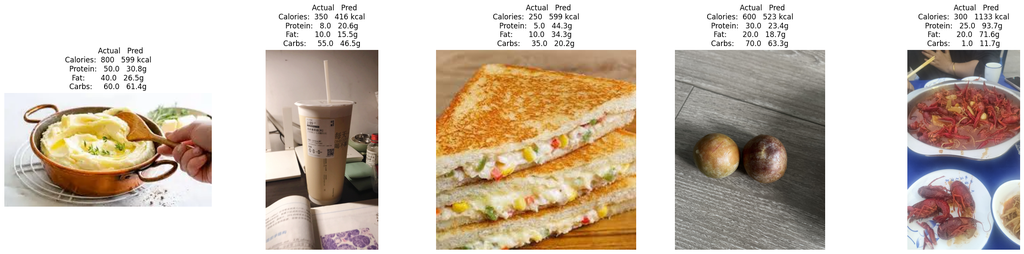

```python
import random

random.seed(42)
num_images = 5

NUTRIENT_LABELS = ['Calories (kcal)', 'Protein (g)', 'Fat (g)', 'Carbs (g)']
norms = NORMS.cpu().numpy()

# Load all test features
all_features, all_labels = [], []
for f in sorted(os.listdir(feature_dir)):
    if f.startswith('test_') and f.endswith('.pt'):
        feats, labs = torch.load(os.path.join(feature_dir, f))
        all_features.append(feats)
        all_labels.append(labs)

all_features = torch.cat(all_features, dim=0)
all_labels = torch.cat(all_labels, dim=0)

# Pick random samples and run model
indices = random.sample(range(len(all_features)), num_images)

model.eval()
with torch.no_grad():
    preds  = (model(all_features[indices].to(device)) * NORMS.to(device)).cpu().numpy()
    labels = (all_labels[indices] * NORMS).numpy()

# Plot
test_images = dataset['test'].cast_column('image_url', HFImage())
fig, axes = plt.subplots(1, num_images, figsize=(5 * num_images, 6))

for ax, idx, pred, true in zip(axes, indices, preds, labels):
    ax.imshow(test_images[idx]['image_url'])
    ax.axis('off')
    title = f"           Actual   Pred\nCalories:  {true[0]:.0f}   {pred[0]:.0f} kcal\nProtein:   {true[1]:.1f}   {pred[1]:.1f}g\nFat:       {true[2]:.1f}   {pred[2]:.1f}g\nCarbs:     {true[3]:.1f}   {pred[3]:.1f}g"
    ax.set_title(title)

plt.tight_layout()
plt.show()
```

## Step 5c. Augmented Data

We also performed testing on augmented data with the following augmentations:

- **SmallestMaxSize**: Standardizes every image by resizing the smallest side to 512 pixels, preserving the original aspect ratio to prevent distortion.
- **Affine Transform**: A comprehensive geometric operation that performs simultaneous translation (shifting the food left/right/up/down), rotation (tilting between -45° and 45°), and scaling (zoom in/out by 0.8x to 1.2x).
- **Random Resized Crop**: Selects a random crop (40% to 100% of the original area) and scales it back to 512x512. This simulates zooming in on specific ingredients or plates.
- **Horizontal & Vertical Flips**: Mirrored reflections of the images. Since food does not have a "correct" left-to-right orientation, this effectively doubles your effective data diversity.

[figure not shown]

# Step 6. Discussion and Results

- **Nutrition Counting** - getting precise nutritional amounts in a meal is not an exact science. For example, measurements of ingredients is not precise. One can cut a reasonable amount of bell pepper or chicken into their meal with a rough estimate of the amount of grams without weighing them. On top of that, certain methods alter the nutritional values (e.g. boiling dissolves water-soluble vitamins), and the exact amount and temperature of these processes also aren't precise when cooking. Even identical foods can have varying nutrition due to soil conditions, ripeness, storage, and more. People also may store food differently and for different amounts of time which also affect the nutritional composition.
- **Using single images** - our project aims for convenience while performing reasonably accurate. Its main purpose is to get a reasonable amount of key nutritional values that anyone can reasonably use just by taking one image of a meal. It's also important to note that in computer, a single monocular image itself is not sufficient for deeper tasks, such as depth estimation and 3D reconstruction (e.g. SFM, NERF, Gaussian Splatting) which require multiple images. 3D volumetric data would provide far richer data for estimating amounts of food, which can guide more accurate estimation of nutritional amounts. Going directly from one image to regressed values is not the most expressive pipeline for estimation.

It is also important to note that the nutritional amounts don't seem to represent continuous values, but rather "bins" that are half of the second least significant digit. For example, for values in the magnitude of hundreds, they will be 100, 150, 200, 250, etc. which is fairly coarse and subject to errors.

# Appendix: Related Works and Citations.

Our primary work focused on training on features derived from the Food-100K dataset [1] with pre-training on the Food2K dataset [2]. There are also other widely-used food datasets, such as Food-101 [3], which is used for discriminative task (classification of 101 food categories given images).

There are also easy to use online tools, such as [here](https://happyforks.com/analyzer/result), where you can input the recipe to get estimated amounts of nutritional profile. However, the purpose of our project is to have an easy solution to estimate these amounts simply by taking a photo of a meal, instead of tediously calculating all the amounts, which is time-consuming.

## Future Work

We believe our project is a simple method that can produce reasonable estimates of nutritional information given an image of a meal, which is simple to gather and requires little pre-processing. For future works, there are multiple avenues to explore:

- Use language embedding to guide prediction. The Food100K dataset provides other features, such as dish name and cooking methods (e.g. pan-frying, deep-frying) which can guide the nutrition estimation. For example, one can reasonably associate deep-frying with higher calories and fats compared to boiling.
- Estimate amount of food. Instead of directly regressing to nutritional information, we can also try to estimate amounts of food to guide the estimation. This can be done with some heuristics, or aided with methods such as instance segmentation to get finer details about elements in the image.
- Estimate more specific nutritional amounts. If portions of the ingredients can be estimated reasonably, these can be used in tabulated datasets of food ([example](https://www.kaggle.com/datasets/utsavdey1410/food-nutrition-dataset/data)) for a fine-grained breakdown of the nutritional values. For example, instead of just fat, it will estimate saturated, monosaturated, and polysatured fats, and carbohydrates can be broken down into fiber and sugar.
- We can also perform image segmentation on the individual ingredients of the meal, such as in [4] (example outputs shown in the image below) and use these segmented instances to estimate the portion amount which can be used to estimate calorie amount.

[figure not shown]

## Citations

[1] Y. Dong, Y. Muraoka, S. Shi, and Y. Zhang, "MM-Food-100K: A 100,000-Sample Multimodal Food Intelligence Dataset with Verifiable Provenance," *arXiv preprint arXiv:2508.10429*, 2025.

[2] W. Min, Z. Wang, Y. Liu, M. Luo, L. Kang, X. Wei, X. Wei, and S. Jiang, "Large scale visual food recognition," *IEEE Transactions on Pattern Analysis and Machine Intelligence*, vol. 45, no. 8, pp. 9932--9949, 2023.

[3] L. Bossard, M. Guillaumin, and L. Van Gool, "Food-101 -- Mining Discriminative Components with Random Forests," in *European Conference on Computer Vision*, 2014.

[4] X. Wu, X. Fu, Y. Liu, E.P. Lim, and S. Hoi, Steven, and Q. Sun, "A large-scale benchmark for food image segmentation", in Proceedings of the 29th ACM international conference on multimedia, pp. 506--515, 2021.